# In-house training for UAMECO lab

## 3.15 **Niche similarity**

Next in line, is for us to test whether the niches of the species pairs are similar:

```r
## ============================================================================##
## Niche similarity -----
## ============================================================================##

## If p < 0.05, then the niche is significantly similar.

similarity_test_set_ver <- ecospat.niche.similarity.test2(z_set, z_ver, 100,
    alternative = "greater", ncores = 23)
similarity_test_ver_set <- ecospat.niche.similarity.test2(z_ver, z_set, 100,
    alternative = "greater", ncores = 23)

similarity_test_set_vir <- ecospat.niche.similarity.test2(z_set, z_vir, 100,
    alternative = "greater", ncores = 23)
similarity_test_vir_set <- ecospat.niche.similarity.test2(z_vir, z_set, 100,
    alternative = "greater", ncores = 23)

similarity_test_ver_vir <- ecospat.niche.similarity.test2(z_ver, z_vir, 100,
    alternative = "greater", ncores = 23)
similarity_test_vir_ver <- ecospat.niche.similarity.test2(z_vir, z_ver, 100,
    alternative = "greater", ncores = 23)

## setosa
similarity_test_set_ver$p.D
similarity_test_ver_set$p.D
similarity_test_set_vir$p.D
similarity_test_vir_set$p.D

## versicolor
similarity_test_ver_vir$p.D  ## Significantly similar
similarity_test_vir_ver$p.D  ## Significantly similar
## ============================================================================##
```

[output not shown]

## 3.16 **Visualise the niche differences**

We are now able to graphically demonstrate the niche differentiation between the three species:

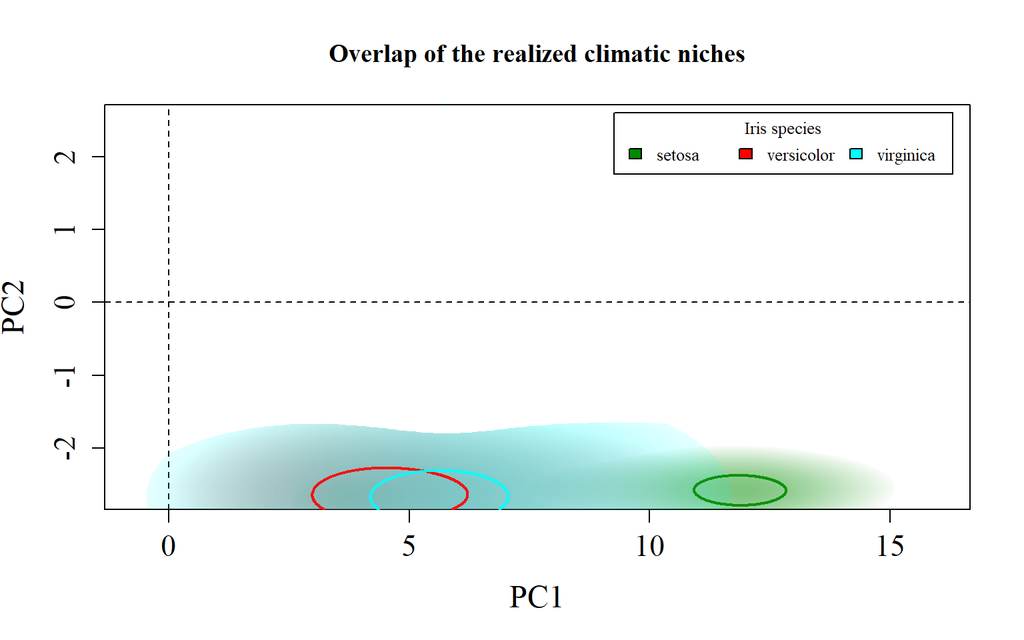

```r
## ============================================================================##
## Create a list with the Dynamic Occurrencies Density Grids
## ============================================================================##
z_list <- list(z_set, z_ver, z_vir)
## ============================================================================##


## ============================================================================##
## Source some scripts -----
## ============================================================================##
source("C:/Users/User/Downloads/NKUA/Multiple regions.R")
## ============================================================================##


## ============================================================================##
## Plot ----
## ============================================================================##
## The results can be seen here. The strong contours represent the 5% highest
## values of density, and the thin lines represent 100% of the background
## available in each region.

library(extrafont)
loadfonts(device = "win")

par(family = "Times New Roman")

g.names <- c("setosa", "versicolor", "virginica")
g.colors <- c("green4", "red", "cyan")

plot.niche.all(z_list, 3, g.names, contornar = TRUE, densidade = TRUE, quantis = 10,
    back = FALSE, title = "Overlap of the realized climatic niches", g.colors,
    n = 2, cor1)

title(main = "Overlap of the realized climatic niches")

legend("topright", inset = 0.02, title = "Iris species", c("setosa", "versicolor",
    "virginica"), fill = c("green4", "red", "cyan"), horiz = TRUE, cex = 0.8)
```

```r
## ============================================================================##
```

You can have a look into (Aguirre-Gutiérrez et al., 2015; Nunes & Pearson, 2017; Datta et al., 2019; Hiller et al., 2019), for instance if you want to know more about this kind of analysis and the subject of niche divergence/similarity.

# **References**

Aguirre-Gutiérrez, J., Serna-Chavez, H.M., Villalobos-Arambula, A.R., Perez de la Rosa, J.A., & Raes, N. (2015) Similar but not equivalent: Ecological niche comparison across closely–related m exican white pines. *Diversity and distributions*, **21**, 245–257.

Datta, A., Schweiger, O., & Kühn, I. (2019) Niche expansion of the invasive plant species ageratina adenophora despite evolutionary constraints. *Journal of Biogeography*, **46**, 1306–1315.

Hiller, A.E., Koo, M.S., Goodman, K.R., Shaw, K.L., O’Grady, P.M., & Gillespie, R.G. (2019) Niche conservatism predominates in adaptive radiation: Comparing the diversification of hawaiian arthropods using ecological niche modelling. *Biological Journal of the Linnean Society*, **127**, 479–492.

Nunes, L.A. & Pearson, R.G. (2017) A null biogeographical test for assessing ecological niche evolution. *Journal of Biogeography*, **44**, 1331–1343.

Pyron, R.A., Costa, G.C., Patten, M.A., & Burbrink, F.T. (2015) Phylogenetic niche conservatism and the evolutionary basis of ecological speciation. *Biological Reviews*, **90**, 1248–1262.

[^1]: The are in the file you downloaded when we first started this practical
[^2]: They are in the [GitHub link](https://github.com/kostask84/EKPA_In_house_practicals/tree/master), in the `Abiotic data` folder
[^3]: Unfortunately, for this kind of analysis we need **at least 5** occurrences

[Kostas Kougioumoutzis](https://www.kkougiou.com/)

Spring semester 2019-2020